# 8_bruv

*NOT SURE IF WE ACTUALLY NEED TO INCLUDE THIS FOR JUST LOOKING AT OCCURRENCE DATA*

Notes from Dave: - We remove any samples if they are more than 40% obscured, as there is a good chance we can’t see any sharks/rays due to the obstruction (look in column titled “% obstruction”; - Some of the BRUV deployments did not film for the full 60 min, for whatever reason. As such, we use a cut off point of 80% to include the record in the analysis. I.e. if the video records for 60*80% = 48 min or more, then we keep it in the analysis. If less than 48 min, remove from analysis; - For MaxN, only use the data from those records which say “Analysis” under the “Period” column. Any records which say “Extra time” or “On descent” should not be included in the analysis, however these can be used to see what species occur in a certain area. - In the “Length data” sheet, I noticed that the lengths were not correct. We have sorted this out, whereby there is a new column called “Final length (mm)”. For sharks this final length = FL and for rays = DW. If you need TL for sharks, you can find lenght-length equations on Fishbase for many (but not all) the species, to work out TL from FL. I have attached the spreadsheet again, which includes the Final FL/DW for the individuals measured. - also forgot to mention, in addition to removing the obscured and deployments that fall under 48 min, also look at “Orientation”. Any BRUVs that are facing “Up” (i.e. pointed towards the sea surface) must be removed for the analysis too, as these are essentially filming a different habitat (the pelagic habitat), and so should not be included together with the other samples.

## *WCS BRUV MaxN data*

Unsure about the length sheet…

### *STEP 1: Read in WCS BRUV data*

### *STEP 2: Read in Mozambique EEZ sf and raster*

### *STEP 3: Create a sf object of BRUV data*

```r
## Create a data frame that only contains the lat/long coordinates and an id number
wcs_mz_bruv_maxn_points <- wcs_mz_bruv_maxn %>%
  select(lat_x, long_y,genus_species) %>%
  drop_na(long_y) %>%  # had to remove NAs for the next function to work
  mutate(id=1:n())

## count the number of speces identified
count_species <- wcs_mz_bruv_maxn_points %>%
  group_by(genus_species) %>%
  summarize(count = n())

# Change `NA` values of names with `Unknown`:
wcs_mz_bruv_maxn_points$genus_species[is.na(wcs_mz_bruv_maxn_points$genus_species)] <- "Unknown"

## Convert the data frame to a simple features object (sf) to create a geometry for each id
wcs_bruv_sf_maxn  <-  st_as_sf(wcs_mz_bruv_maxn_points, coords = c("long_y", "lat_x"), crs= 4326) %>%
  st_transform(., crs = st_crs(mz_eez_sf)) # tranform to match the mz_eez crs


## check to make sure it matches
st_crs(wcs_bruv_sf_maxn)
```

[output not shown]

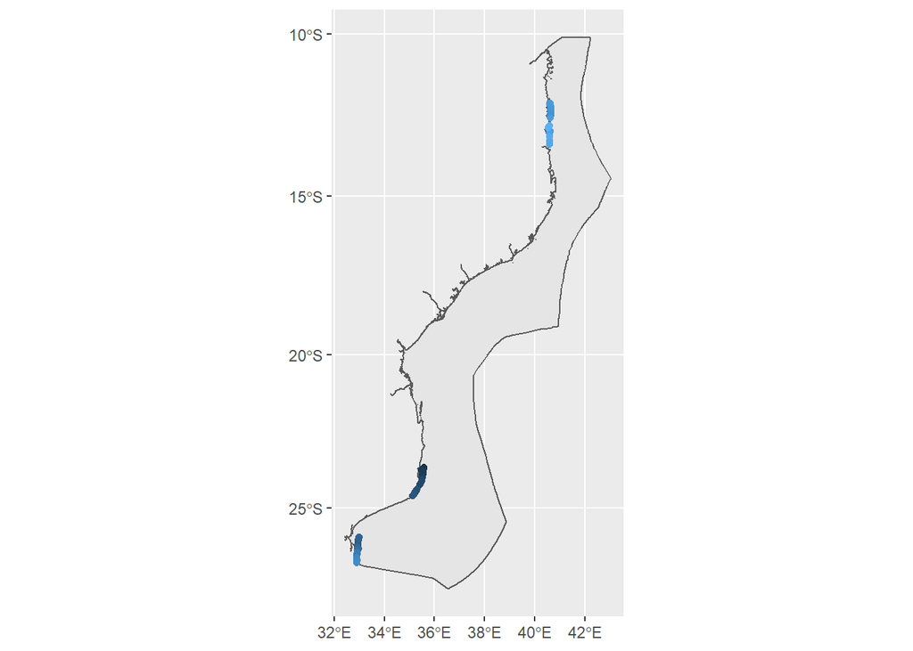

```r
## plot to see what it looks like
ggplot() +
  geom_sf(data = mz_eez_sf) +
  geom_sf(data = wcs_bruv_sf_maxn, aes(color = id),
          show.legend = FALSE)
```

```r
tmap_mode("view") # Set to interactive viewing

tm_shape(wcs_bruv_sf_maxn) +
  tm_dots("genus_species", clustering = T, legend.show = FALSE, size = 0.5)
```

[interactive chart not shown]

```r
  #tm_basemap("Stamen.Terrain")
```

## *POPMR BRUV data*

Follow the same steps as above.

## *Northern Mozambique BRUV data*

Follow the same steps as above. *THIS DATASET IS OVER 1 MILLION OBSERVATIONS DON’T PUT ON GITHUB*